# Multivariate Fish Analysis

Nick Toimieri

# 1 Intro

This is an up-dated fish file with only the “final” fish multivariate analyses for the Foundational MS.

# 2 Import and manipulate data

For data processing:

- Corrected some spp codes
- Make a ‘group’ variable for lumping taxa/species
- Combined 2015 and 2016-2019 data
  - 2015 data are not necessarily used in analyses
  - 2015 data lack visibility estimates
- No depth data for the 2015 data.
  - I took the average of the quadrats.
  - I assigned transects with an average depth of >20 ft to the 10-m group.

NOTE: Transects with visibility < 2 m were deleted from the analysis.

NOTE: These analyses DO NOT include 2015.

DATA TRANSFORM: none

I set the data transform to ‘none’ because there wasn’t a lot of variation in spp density among groups. Some but not a lot. Again, this emphasizes the more abudnant species, which is, I think, ok.

NOTES

- Some rockfish were recorded in the ‘adult’ category (eg SECA instead of SECAy) but were small.
- Set minimum size for rockfishes to 6 cm. Fish <= to 6 cm were classified as YOY.
- Maintained their original desigation in SPECIES column. New designation in the ‘group’ column.

Because there were a lot of zeros for some species, we lumped some species or taxa them into higher taxonomic categories. Species higher grouping used in the analyses are:

```
##    Spp_Code Spp_Group            Common_Name
## 1  BAITBALL      BAIT  bait-sardines-anchovy
## 4    SEBYTy    SEBYTy   yellowtail-black yoy
## 5      SEME      SEME         black rockfish
## 8      SEMY      SEMY          blue rockfish
## 12     SCMA      SCMA                cabezon
## 14    SEPIy     SEPIy    canary rockfish YOY
## 15     SENE      SENE         china rockfish
## 17     SECA      SECA        copper rockfish
## 20     HEXA      HEXA        Hexagrammos spp
## 23     CLUP      BAIT                Herring
## 25     HEDE      HEXA         Kelp Greenling
## 26     BRFR      EMBI         Kelp Surfperch
## 29     OPEL      OPEL                Lingcod
## 34     ENMO      BAIT       Northern Anchovy
## 38     SASA      BAIT        pacific sardine
## 39     OXPI      HEXA      Painted Greenling
## 41     RHVA      EMBI             Pile perch
## 45     HEHE      HEXA         Red Irish Lord
## 47     HELA      HEXA         Rock Greenling
## 49     RYOY      RYOY           rockfish_yoy
## 55     CYAG      EMBI       Shiner Surfperch
## 60     EMLA      EMBI      Striped Surfperch
## 61     EMBI      EMBI            Surfperches
## 63     AUFL      AUFL              Tubesnout
## 66     HEST      HEXA Whitespotted greenling
## 68     SEFL      SEFL    Yellowtail rockfish
```

## 2.1 Year x Site x Depth

No text here. Just calculating averages by year x site x depth and outputting data.

## 2.2 Year x Site

No text here. Just calculating averages by year x site and outputting data.

# 3 Constrained Ordinations

Note: there are no rockfish YOY in these ordinations and analyses.

DATA TRANSFORM: none

We deleted YOY from the analyses because they were highly variable and often appeared in only one year. Taxa included in the actual analyses were:

Taxa Included: OPEL, HEXA, EMBI, AUFL, BAIT, SECA, SCMA, SENE, SEFL, SEME

## 3.1 Basic - Discriminat CAP Site x Depth x Year

### 3.1.1 Permanova

In the PerMANVOA everything is significant. I think this is OK. Things are messy.

The associated ordination is more clear. This ordination uses site x year x depth as groups and transects as replicates. I have, however, calculated the centroids for plotting.

FYI removing BAIT doesn’t do much.

```
## Permutation: free
## Number of permutations: 999
##
## Terms added sequentially (first to last)
##
##                 Df SumsOfSqs MeanSqs F.Model      R2 Pr(>F)
## SITE             4     2.649 0.66230  3.7346 0.08283  0.001 ***
## ZONE             1     1.400 1.39970  7.8928 0.04376  0.001 ***
## YEAR             1     0.779 0.77873  4.3912 0.02435  0.001 ***
## SITE:ZONE        4     1.288 0.32197  1.8155 0.04026  0.013 *
## SITE:YEAR        4     1.819 0.45468  2.5639 0.05686  0.001 ***
## ZONE:YEAR        1     0.791 0.79100  4.4604 0.02473  0.001 ***
## SITE:ZONE:YEAR   4     1.447 0.36181  2.0402 0.04525  0.002 **
## Residuals      123    21.813 0.17734         0.68196
## Total          142    31.985                 1.00000
## ---
## Signif. codes:  0 '***' 0.001 '**' 0.01 '*' 0.05 '.' 0.1 ' ' 1
```

### 3.1.2 CAP

### 3.1.3 capscale - site x year x depth

To match PerMANOVA

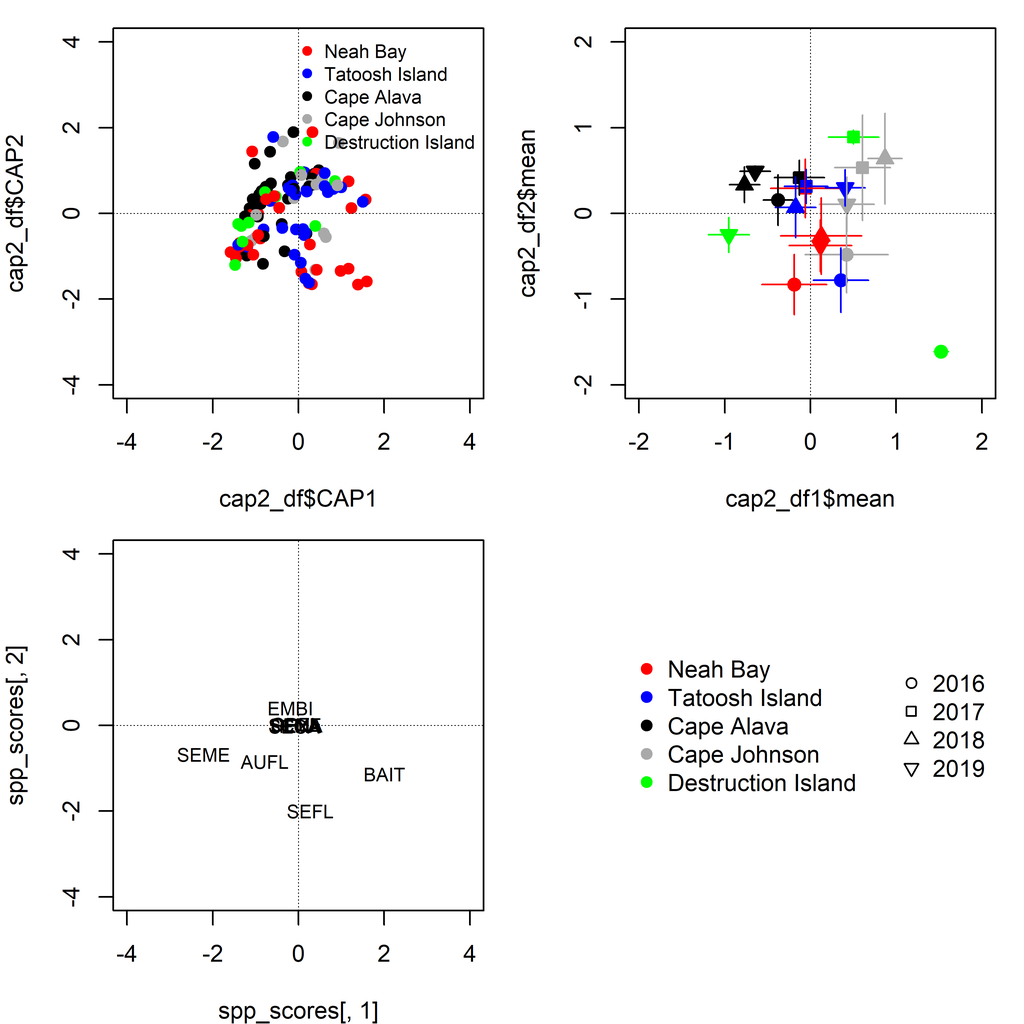

Ordination plot for CAP based on site x year x depth. Error bars are +/- 1.0 s.e.

Same data replotted on one pane. We can see some clear site differences:

- Cape Alava and Cape Johnson do not overlap
- Tatoosh and Neah Bay are intermediate between the former two
- Destruction is all over the place

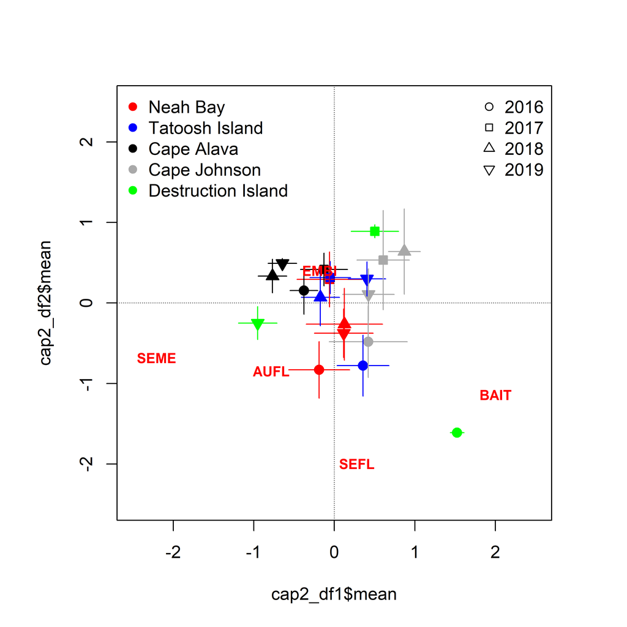

Ordination plot for CAP based on site x year x depth. Error bars are +/- 1.0 s.e.

- PCA the various habitat variables to reduces dimensions
- Do separately for each variable type
- Initial analysis by depth zone to maintain the most replicates
  - not necessarily interested in depth for the analyses

## 3.2 Substrate PCA - YEAR x SITE x DEPTH means

While there is some variation among years within sites (spread), it isn’t bad. Mostly, there are some obvious differences among sites with regard to habitat.

This might be a good initial ordination figure just describing the sites and showing that the physcial habitat differs among sites. Depths to a lesser extent.

- Tatoosh and Destruction Island have more bedrock and higher relief than other areas.
- Neah Bay is bascially intermediate for everything.
- Cape Alava and Cape Johnson have more boulder and kind of intermediate relief.

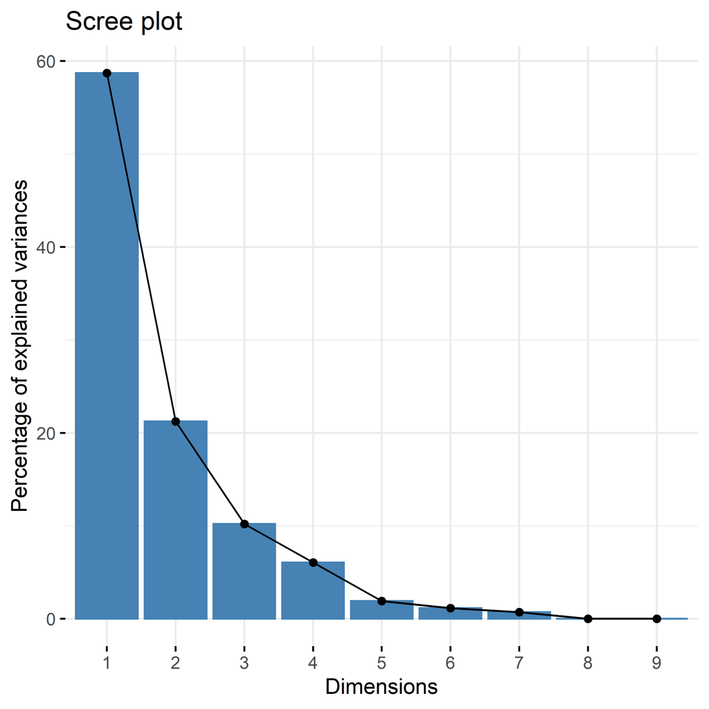

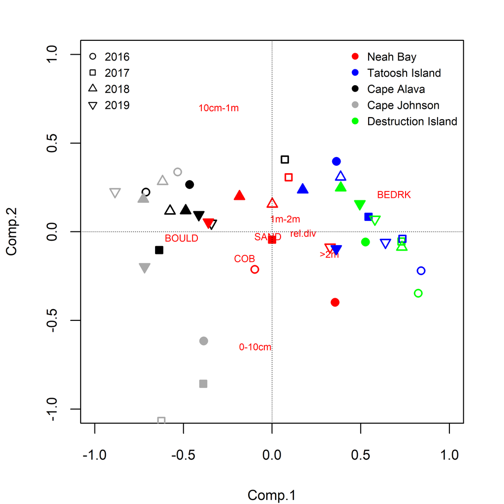

Substrate PCA. Open circles are 5-m depth zone; closed circles 10-m depth zone.

### 3.2.1 Fish vs abiotic habitat and kelp

I combined the PCs from the habitat analysis with the kelp data. I then ran and RDA style constrained analysis.

This constrained habitat vs. fish analysis is ugly. In fact, it is non-significant! So while there are differences among sites x depth x year in fish abundance, they don’t seem related to habitat directly.

This actually makes sense when you compare the separate fish and habitat ordinations. For example, Cape Alava and Cape Johnson have different fish fauna, but similar habitat.

```
## Call: capscale(formula = cap_data[, cap.fish] ~ Comp.1 + Comp.2 +
## MACPYR + NERLUE + OTHER + PTECAL, data = cap_data)
##
##                 Inertia Proportion Rank
## Total         1527.7263     1.0000
## Constrained    226.3166     0.1481    6
## Unconstrained 1301.4097     0.8519   10
## Inertia is mean squared Euclidean distance
## Species scores projected from '[' 'cap_data' '' 'cap.fish'
##
## Eigenvalues for constrained axes:
##   CAP1   CAP2   CAP3   CAP4   CAP5   CAP6
## 191.88  27.34   5.73   1.20   0.11   0.06
##
## Eigenvalues for unconstrained axes:
##   MDS1   MDS2   MDS3   MDS4   MDS5   MDS6   MDS7   MDS8   MDS9  MDS10
## 1060.9  189.7   40.6    8.1    1.4    0.3    0.2    0.1    0.1    0.0
```

```
## Permutation test for capscale under reduced model
## Permutation: free
## Number of permutations: 999
##
## Model: capscale(formula = cap_data[, cap.fish] ~ Comp.1 + Comp.2 + MACPYR + NERLUE + OTHER + PTECAL, data = cap_data)
##          Df Variance      F Pr(>F)
## Model     6   226.32 0.8405  0.526
## Residual 29  1301.41
```

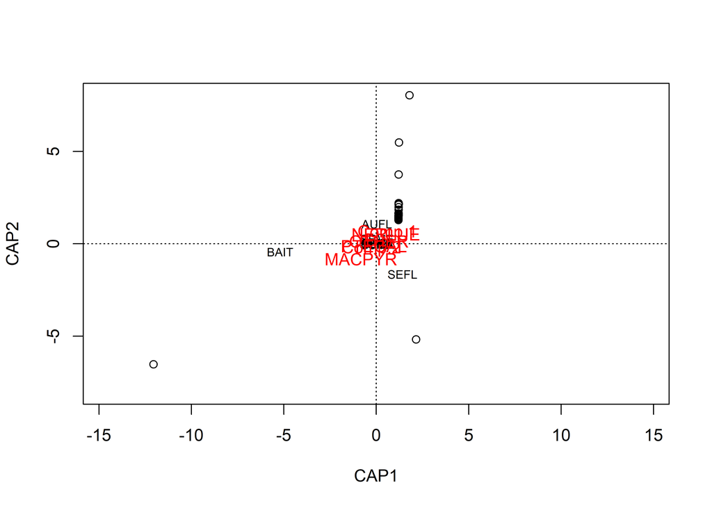

***

# 4 Univariate plots by group

Note: I have plotted YOY here but they are not in the above ordinations.

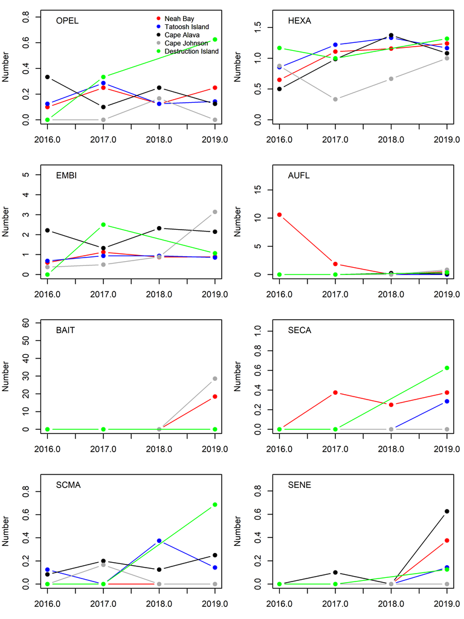

Fish abundance by site and year.

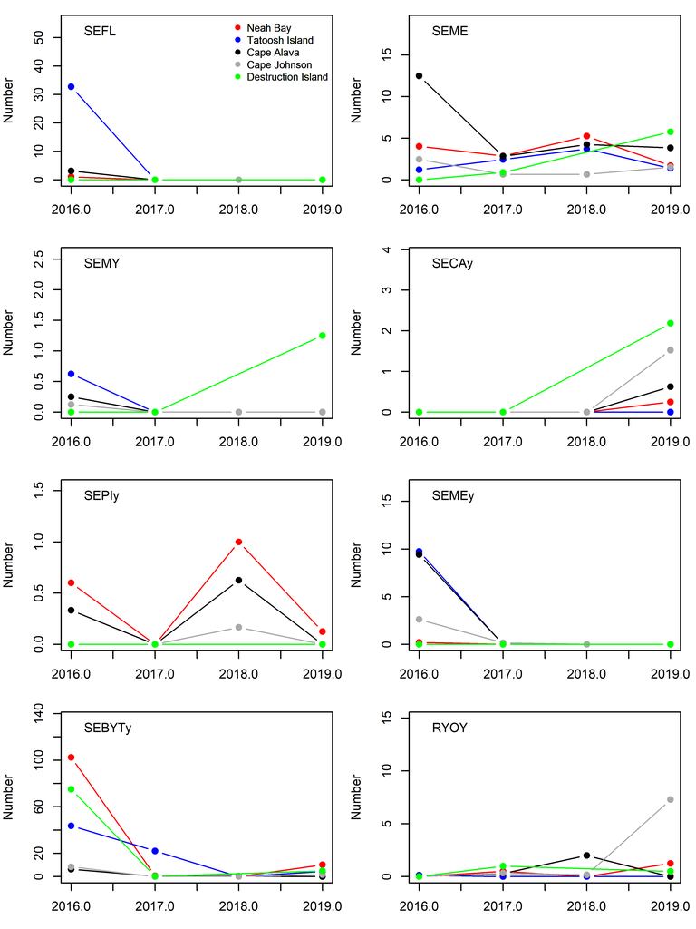

Fish abundance by site and year.